# YANG_XINYI-PS1

## About the Problem Set:

This problem set is rather similar to ones used for R, dplyr, and flights data. Just we use python and pandas.

Your task is to analyze the nycflights13 data (in the R package of the same name). The necessary csv files are provided on canvas (in files/data). An easy way to get the explanations is on the the [package page on R documentation](https://www.rdocumentation.org/packages/nycflights13/versions/1.0.0).

In this problem set you will perform a basic exploratory analysis on an example dataset, bringing to bear all of your new skills in data manipulation and visualization. You will be required to submit well commented python code, documenting all code used in this problem set, along with a write up answering all questions below. Use figures as appropriate to support your answers, and when required by the problem.

Always comment your results, preferably in a separate markdown cell.

## Preliminaries

You should also make sure the following libraries load correctly. Below are a few basic data description tasks already done for you.

```python
#IPython is what you are using now to run the notebook
import IPython
print( "IPython version:      %6.6s (need at least 1.0)" % IPython.__version__)

# Numpy is a library for working with arrays and matrices
import numpy as np
print( "Numpy version:        %6.6s (need at least 1.7.1)" % np.__version__)

# SciPy implements many different numerical algorithms
import scipy as sp
print( "SciPy version:        %6.6s (need at least 0.12.0)" % sp.__version__)

# Pandas makes working with data tables easier
import pandas as pd
print( "Pandas version:       %6.6s (need at least 0.11.0)" % pd.__version__)

# Module for plotting
import matplotlib.pyplot as plt
from pylab import *
print( "Mapltolib version:    %6.6s (need at least 1.2.1)" %
       matplotlib.__version__)
%matplotlib inline
# necessary for in-line graphics

# SciKit Learn implements several Machine Learning algorithms
import sklearn
print( "Scikit-Learn version: %6.6s (need at least 0.13.1)" %
       sklearn.__version__)
import os
# for certain system-related functions
```

```
IPython version:      7.11.1 (need at least 1.0)
Numpy version:        1.17.4 (need at least 1.7.1)
SciPy version:         1.3.2 (need at least 0.12.0)
Pandas version:       0.25.3 (need at least 0.11.0)
Mapltolib version:     3.1.1 (need at least 1.2.1)
Scikit-Learn version:   0.22 (need at least 0.13.1)
```

```python
## Let's read the data and print some summary information
## adjust the path for your file system!
## you can find the path like this:
path = os.getcwd()
print(path)
flights_df= pd.read_csv('data/flights.csv')
```

```
C:\Users\Zhu\OneDrive - UW\574
```

```python
## Extract some basic information about the data like number of rows,
## columns, column names, data types
print(flights_df.shape)
print(flights_df.columns)
print(flights_df.dtypes)
```

```
(336776, 17)
Index(['Unnamed: 0', 'year', 'month', 'day', 'dep_time', 'dep_delay',
       'arr_time', 'arr_delay', 'carrier', 'tailnum', 'flight', 'origin',
       'dest', 'air_time', 'distance', 'hour', 'minute'],
      dtype='object')
Unnamed: 0      int64
year            int64
month           int64
day             int64
dep_time      float64
dep_delay     float64
arr_time      float64
arr_delay     float64
carrier        object
tailnum        object
flight          int64
origin         object
dest           object
air_time      float64
distance        int64
hour          float64
minute        float64
dtype: object
```

```python
## print the first and last few lines of the data
print("head\n", flights_df.head())
print("tail\n", flights_df.tail())
## Find the number of unique destinations in the data ('dest')
print("destinations:\n", flights_df.dest.unique())
```

```
head
    Unnamed: 0  year  month  day  dep_time  dep_delay  arr_time  arr_delay  \
0           1  2013      1    1     517.0        2.0     830.0       11.0
1           2  2013      1    1     533.0        4.0     850.0       20.0
2           3  2013      1    1     542.0        2.0     923.0       33.0
3           4  2013      1    1     544.0       -1.0    1004.0      -18.0
4           5  2013      1    1     554.0       -6.0     812.0      -25.0

  carrier tailnum  flight origin dest  air_time  distance  hour  minute
0      UA  N14228    1545    EWR  IAH     227.0      1400   5.0    17.0
1      UA  N24211    1714    LGA  IAH     227.0      1416   5.0    33.0
2      AA  N619AA    1141    JFK  MIA     160.0      1089   5.0    42.0
3      B6  N804JB     725    JFK  BQN     183.0      1576   5.0    44.0
4      DL  N668DN     461    LGA  ATL     116.0       762   5.0    54.0
tail
         Unnamed: 0  year  month  day  dep_time  dep_delay  arr_time  \
336771      336772  2013      9   30       NaN        NaN       NaN
336772      336773  2013      9   30       NaN        NaN       NaN
336773      336774  2013      9   30       NaN        NaN       NaN
336774      336775  2013      9   30       NaN        NaN       NaN
336775      336776  2013      9   30       NaN        NaN       NaN

        arr_delay carrier tailnum  flight origin dest  air_time  distance  \
336771        NaN      9E     NaN    3393    JFK  DCA       NaN       213
336772        NaN      9E     NaN    3525    LGA  SYR       NaN       198
336773        NaN      MQ  N535MQ    3461    LGA  BNA       NaN       764
336774        NaN      MQ  N511MQ    3572    LGA  CLE       NaN       419
336775        NaN      MQ  N839MQ    3531    LGA  RDU       NaN       431

        hour  minute
336771   NaN     NaN
336772   NaN     NaN
336773   NaN     NaN
336774   NaN     NaN
336775   NaN     NaN
destinations:
 ['IAH' 'MIA' 'BQN' 'ATL' 'ORD' 'FLL' 'IAD' 'MCO' 'PBI' 'TPA' 'LAX' 'SFO'
 'DFW' 'BOS' 'LAS' 'MSP' 'DTW' 'RSW' 'SJU' 'PHX' 'BWI' 'CLT' 'BUF' 'DEN'
 'SNA' 'MSY' 'SLC' 'XNA' 'MKE' 'SEA' 'ROC' 'SYR' 'SRQ' 'RDU' 'CMH' 'JAX'
 'CHS' 'MEM' 'PIT' 'SAN' 'DCA' 'CLE' 'STL' 'MYR' 'JAC' 'MDW' 'HNL' 'BNA'
 'AUS' 'BTV' 'PHL' 'STT' 'EGE' 'AVL' 'PWM' 'IND' 'SAV' 'CAK' 'HOU' 'LGB'
 'DAY' 'ALB' 'BDL' 'MHT' 'MSN' 'GSO' 'CVG' 'BUR' 'RIC' 'GSP' 'GRR' 'MCI'
 'ORF' 'SAT' 'SDF' 'PDX' 'SJC' 'OMA' 'CRW' 'OAK' 'SMF' 'TUL' 'TYS' 'OKC'
 'PVD' 'DSM' 'PSE' 'BHM' 'CAE' 'HDN' 'BZN' 'MTJ' 'EYW' 'PSP' 'ACK' 'BGR'
 'ABQ' 'ILM' 'MVY' 'SBN' 'LEX' 'CHO' 'TVC' 'ANC' 'LGA']
```

## Some Tips

- This assignment involves extensive Data frame splitting and aggregation. You should look into the details of the methods groupby, transform, sum, count, mean etc
- Many of the tasks in the assignment can be done either through the Pandas Data Frame or by converting the data frames to Series. Many of the methods in the numpy are applicable to Series only. When stuck, try to explore the type of object (Pandas Data Frame or Numpy Series) you are dealing with.

## Question 1

Let’s explore flights from NYC to LA. Use the flights dataset to answer the following questions.

### (a)

How many flights were there from NYC airports to Los Angeles International Airport (LAX) in 2013?

```python
# Your code here
flights_df=pd.DataFrame(flights_df)
flights_df
```

|  | Unnamed: 0 | year | month | day | dep_time | dep_delay | arr_time | arr_delay | carrier | tailnum | flight | origin | dest | air_time | distance | hour | minute |
| --- | --- | --- | --- | --- | --- | --- | --- | --- | --- | --- | --- | --- | --- | --- | --- | --- | --- |
| 0 | 1 | 2013 | 1 | 1 | 517.0 | 2.0 | 830.0 | 11.0 | UA | N14228 | 1545 | EWR | IAH | 227.0 | 1400 | 5.0 | 17.0 |
| 1 | 2 | 2013 | 1 | 1 | 533.0 | 4.0 | 850.0 | 20.0 | UA | N24211 | 1714 | LGA | IAH | 227.0 | 1416 | 5.0 | 33.0 |
| 2 | 3 | 2013 | 1 | 1 | 542.0 | 2.0 | 923.0 | 33.0 | AA | N619AA | 1141 | JFK | MIA | 160.0 | 1089 | 5.0 | 42.0 |
| 3 | 4 | 2013 | 1 | 1 | 544.0 | -1.0 | 1004.0 | -18.0 | B6 | N804JB | 725 | JFK | BQN | 183.0 | 1576 | 5.0 | 44.0 |
| 4 | 5 | 2013 | 1 | 1 | 554.0 | -6.0 | 812.0 | -25.0 | DL | N668DN | 461 | LGA | ATL | 116.0 | 762 | 5.0 | 54.0 |
| ... | ... | ... | ... | ... | ... | ... | ... | ... | ... | ... | ... | ... | ... | ... | ... | ... | ... |
| 336771 | 336772 | 2013 | 9 | 30 | NaN | NaN | NaN | NaN | 9E | NaN | 3393 | JFK | DCA | NaN | 213 | NaN | NaN |
| 336772 | 336773 | 2013 | 9 | 30 | NaN | NaN | NaN | NaN | 9E | NaN | 3525 | LGA | SYR | NaN | 198 | NaN | NaN |
| 336773 | 336774 | 2013 | 9 | 30 | NaN | NaN | NaN | NaN | MQ | N535MQ | 3461 | LGA | BNA | NaN | 764 | NaN | NaN |
| 336774 | 336775 | 2013 | 9 | 30 | NaN | NaN | NaN | NaN | MQ | N511MQ | 3572 | LGA | CLE | NaN | 419 | NaN | NaN |
| 336775 | 336776 | 2013 | 9 | 30 | NaN | NaN | NaN | NaN | MQ | N839MQ | 3531 | LGA | RDU | NaN | 431 | NaN | NaN |

336776 rows × 17 columns

```python
target_flights= flights_df[flights_df.dest=='LAX']
flight_uniq=target_flights['flight'].unique()
flight_uniq.shape
```

```
(399,)
```

### (b)

Which airline ('carrier') has the most flights from NYC to LAX? Which one has the least number of flights? Report the numbers respectively.

```python
# Your code here
# Check number of flights for each airline
car=pd.Series(target_flights.carrier)
uniques = car.unique()
uniques
```

```
array(['UA', 'VX', 'B6', 'AA', 'DL'], dtype=object)
```

only get the carrier column and make it a pandas series and find out the names of the carriers

```python
car.value_counts()
```

```
UA    5823
AA    3582
VX    2580
DL    2501
B6    1688
Name: carrier, dtype: int64
```

use value_counts to find out the most and the least

- UA has the most flights from NYC to LAX, which is 5823
- B6 has the least flights, which is 1688

### (c)

How many unique air planes fly from NYC to LAX? (Hint: use 'tailnum', essentially the license plate of airplane)

```python
# Your code here
tn=pd.Series(target_flights['tailnum'])
tn_uniques=tn.unique()
tn_uniques.shape
```

```
(992,)
```

There are 992 air planes.

### (d)

What is the average arrival delay for flights from NYC to LAX?

```python
# Your code here
arr_delay=pd.Series(target_flights.arr_delay)
arr_delay.mean()
```

```
0.5471109447148383
```

The average arrival delay for flights from NYC to LAX is 0.547111

### (e)

What proportion of flights to LAX come from each NYC airport?

```python
# Your code here
ori=pd.Series(target_flights.origin)
ori_counts=ori.value_counts()
proportion=ori.value_counts(normalize=True).mul(100).round(1).astype(str)+'%'
proportion
```

```
JFK    69.6%
EWR    30.4%
Name: origin, dtype: object
```

The proportion of flights to LAX comefrom JFK versus EWR is about 7:3. No flight come from LGA.The exact results are shown above.

- first get the counts
- normalize the counts and multiply 100 and round to 0.1%
- alter the type of the results to string in order to add a "%" after it

## Question 2

Now let's explore the entire NYC flight dataset. Flights are often delayed. Consider the following questions exploring delay patterns.

### (a)

Which date has the largest average departure delay? Which date has the largest average arrival delay?

```python
# Your code here

#sort out the date
flights_df['date'] = flights_df['month'].astype(str) + "." + flights_df['day'].astype(str)
#create a dataframe of average values by date
average_date = pd.DataFrame(flights_df.groupby('date').mean())
#sort by dep_delay with the largest showing on the top line and only output the first line of the DataFrame
average_date.sort_values(by=['dep_delay'],ascending =False).head(1)
```

| date | Unnamed: 0 | year | month | day | dep_time | dep_delay | arr_time | arr_delay | flight | air_time | distance | hour | minute |
| --- | --- | --- | --- | --- | --- | --- | --- | --- | --- | --- | --- | --- | --- |
| 3.8 | 143267.0 | 2013.0 | 3.0 | 8.0 | 1416.659574 | 83.536921 | 1503.931078 | 85.862155 | 2013.537283 | 153.746867 | 1002.540347 | 13.867334 | 29.926158 |

```python
average_date.sort_values(by=['arr_delay'],ascending =False).head(1)
```

| date | Unnamed: 0 | year | month | day | dep_time | dep_delay | arr_time | arr_delay | flight | air_time | distance | hour | minute |
| --- | --- | --- | --- | --- | --- | --- | --- | --- | --- | --- | --- | --- | --- |
| 3.8 | 143267.0 | 2013.0 | 3.0 | 8.0 | 1416.659574 | 83.536921 | 1503.931078 | 85.862155 | 2013.537283 | 153.746867 | 1002.540347 | 13.867334 | 29.926158 |

03/08/2013 has the largest average departure delay and arrival delay.

### (b)

What was the worst day and the best day to fly out of NYC in 2013 if you dislike delayed flights?

Note: we ask the largest delay given there was a (positive) delay, we don't care about flights that were in time or early.

```python
# exclude negative delays
po_delay_flights_df=flights_df[flights_df['dep_delay']>0]
po_delay_flights_df
```

|  | Unnamed: 0 | year | month | day | dep_time | dep_delay | arr_time | arr_delay | carrier | tailnum | flight | origin | dest | air_time | distance | hour | minute | date |
| --- | --- | --- | --- | --- | --- | --- | --- | --- | --- | --- | --- | --- | --- | --- | --- | --- | --- | --- |
| 0 | 1 | 2013 | 1 | 1 | 517.0 | 2.0 | 830.0 | 11.0 | UA | N14228 | 1545 | EWR | IAH | 227.0 | 1400 | 5.0 | 17.0 | 1.1 |
| 1 | 2 | 2013 | 1 | 1 | 533.0 | 4.0 | 850.0 | 20.0 | UA | N24211 | 1714 | LGA | IAH | 227.0 | 1416 | 5.0 | 33.0 | 1.1 |
| 2 | 3 | 2013 | 1 | 1 | 542.0 | 2.0 | 923.0 | 33.0 | AA | N619AA | 1141 | JFK | MIA | 160.0 | 1089 | 5.0 | 42.0 | 1.1 |
| 19 | 20 | 2013 | 1 | 1 | 601.0 | 1.0 | 844.0 | -6.0 | B6 | N644JB | 343 | EWR | PBI | 147.0 | 1023 | 6.0 | 1.0 | 1.1 |
| 25 | 26 | 2013 | 1 | 1 | 608.0 | 8.0 | 807.0 | 32.0 | MQ | N9EAMQ | 3768 | EWR | ORD | 139.0 | 719 | 6.0 | 8.0 | 1.1 |
| ... | ... | ... | ... | ... | ... | ... | ... | ... | ... | ... | ... | ... | ... | ... | ... | ... | ... | ... |
| 336759 | 336760 | 2013 | 9 | 30 | 2207.0 | 27.0 | 2257.0 | 7.0 | MQ | N532MQ | 3660 | LGA | BNA | 97.0 | 764 | 22.0 | 7.0 | 9.30 |
| 336760 | 336761 | 2013 | 9 | 30 | 2211.0 | 72.0 | 2339.0 | 57.0 | EV | N12145 | 4672 | EWR | STL | 120.0 | 872 | 22.0 | 11.0 | 9.30 |
| 336762 | 336763 | 2013 | 9 | 30 | 2233.0 | 80.0 | 112.0 | 42.0 | UA | N578UA | 471 | EWR | SFO | 318.0 | 2565 | 22.0 | 33.0 | 9.30 |
| 336763 | 336764 | 2013 | 9 | 30 | 2235.0 | 154.0 | 59.0 | 130.0 | B6 | N804JB | 1083 | JFK | MCO | 123.0 | 944 | 22.0 | 35.0 | 9.30 |
| 336768 | 336769 | 2013 | 9 | 30 | 2307.0 | 12.0 | 2359.0 | 1.0 | B6 | N565JB | 718 | JFK | BOS | 33.0 | 187 | 23.0 | 7.0 | 9.30 |

128432 rows × 18 columns

```python
# Your code here
#create a new date-grouped dataframe sorted by average departure delay

po_average_date = pd.DataFrame(po_delay_flights_df.groupby('date').mean())
delay_date=po_average_date.sort_values(by=['dep_delay'])
delay_date
print('The worst date for it has the largest average departure delay is')
print(delay_date['dep_delay'].tail(1))
print('The best date is')
print(delay_date['dep_delay'].head(1))
```

```
The worst date for it has the largest average departure delay is
date
3.8    102.903522
Name: dep_delay, dtype: float64
The best date is
date
11.9    17.156028
Name: dep_delay, dtype: float64
```

### (c)

On average which airline has the lowest departure delay for their NYC flights in 2013 in this dataset? and which one has the greatest departure delay?

Note: here we want to include both positive and negative delays (early departures)

```python
# Your code here
avg_airline = pd.DataFrame(flights_df.groupby('carrier').mean())
delay_air=avg_airline.sort_values(by=['dep_delay'])
print('On average the airline has the lowest departure delay for their NYC flights in 2013 in this dataset is')
print (delay_air['dep_delay'].head(1))
print('the airline has the greatest departure delay is')
print(delay_air['dep_delay'].tail(1))
```

```
On average the airline has the lowest departure delay for their NYC flights in 2013 in this dataset is
carrier
US    3.782418
Name: dep_delay, dtype: float64
the airline has the greatest departure delay is
carrier
F9    20.215543
Name: dep_delay, dtype: float64
```

### (d)

Are there any seasonal patterns in departure delays for flights from NYC?

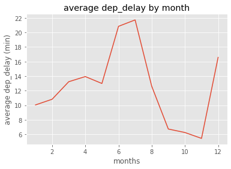

```python
# Your code here
# use ggplot to draw a line chart of average delay by month
plt.style.use('ggplot')
plt.plot(flights_df.groupby('month')['dep_delay'].mean())
plt.xlabel('months', size = 12)
plt.ylabel('average dep_delay (min)', size = 12)
plt.title('average dep_delay by month')
plt.show()
```

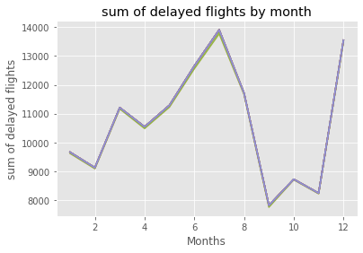

```python
#observing the severity of delay by sum of delayed flights using the positive delay dataframe
plt.plot(po_delay_flights_df.groupby('month').count())
plt.xlabel('Months', size = 12)
plt.ylabel('sum of delayed flights', size = 12)
plt.title('sum of delayed flights by month')
plt.show()
```

It seems like the delay condition peaks during the summer and winter vacation. So it has a seasonal pattern.

### (e)

On average, how do departure delays vary over the course of a day?

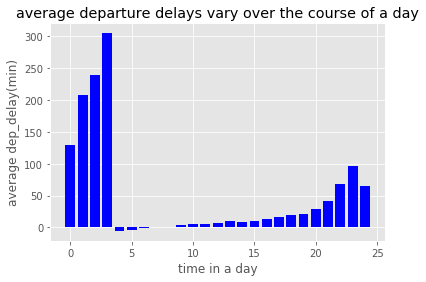

```python
# Your code here
#since it is in a date, so I'll group the average data by hour
dep_delay_hour = pd.DataFrame(flights_df.groupby('hour')['dep_delay'].mean())

# draw a bar chart of how much delayed it is on average
plt.bar(range(25), dep_delay_hour.dep_delay,color='blue')
plt.xlabel('time in a day', size = 12)
plt.ylabel('average dep_delay(min)', size = 12)
plt.title('average departure delays vary over the course of a day')
plt.show()
```

From the bar chart above, flights delay longer in the late night.

## Question 3

Which flight departing NYC in 2013 flew the slowest?

Note: compute the speed as distance/time.

```python
# Your code here
# air_time & distance
#create a new column of speed
flights_df['speed']=flights_df.distance/flights_df.air_time #mile per minute
flights_df.head()
flights_df.sort_values(by=['speed']).head(1)
```

|  | Unnamed: 0 | year | month | day | dep_time | dep_delay | arr_time | arr_delay | carrier | tailnum | flight | origin | dest | air_time | distance | hour | minute | date | speed |
| --- | --- | --- | --- | --- | --- | --- | --- | --- | --- | --- | --- | --- | --- | --- | --- | --- | --- | --- | --- |
| 24098 | 24099 | 2013 | 1 | 28 | 1917.0 | 52.0 | 2118.0 | 103.0 | US | N755US | 1860 | LGA | PHL | 75.0 | 96 | 19.0 | 17.0 | 1.28 | 1.28 |

## Question 4

Which flights (i.e. carrier + flight + dest) happen every day? Where do they fly to?

```python
# Your code here
#create a new column for the combo (i.e. carrier + flight + dest)
flights_df['combo']= flights_df['carrier'].astype(str) + "  " + flights_df['flight'].astype(str) + "  " + flights_df['dest'].astype(str)
#group combo and count how many times each shows up, use the unnamed column to record count
flights_daily = flights_df.groupby('combo').count().sort_values('Unnamed: 0', ascending = False)
flights_daily
```

| combo | Unnamed: 0 | year | month | day | dep_time | dep_delay | arr_time | arr_delay | carrier | tailnum | flight | origin | dest | air_time | distance | hour | minute | date | speed |
| --- | --- | --- | --- | --- | --- | --- | --- | --- | --- | --- | --- | --- | --- | --- | --- | --- | --- | --- | --- |
| UA 15 HNL | 365 | 365 | 365 | 365 | 363 | 363 | 363 | 359 | 365 | 363 | 365 | 365 | 365 | 359 | 365 | 363 | 363 | 365 | 359 |
| B6 371 FLL | 365 | 365 | 365 | 365 | 359 | 359 | 359 | 359 | 365 | 365 | 365 | 365 | 365 | 359 | 365 | 359 | 359 | 365 | 359 |
| AA 181 LAX | 365 | 365 | 365 | 365 | 363 | 363 | 363 | 362 | 365 | 365 | 365 | 365 | 365 | 362 | 365 | 363 | 363 | 365 | 362 |
| B6 219 CLT | 365 | 365 | 365 | 365 | 363 | 363 | 363 | 363 | 365 | 365 | 365 | 365 | 365 | 363 | 365 | 363 | 363 | 365 | 363 |
| AA 119 LAX | 365 | 365 | 365 | 365 | 361 | 361 | 361 | 359 | 365 | 364 | 365 | 365 | 365 | 359 | 365 | 361 | 361 | 365 | 359 |
| ... | ... | ... | ... | ... | ... | ... | ... | ... | ... | ... | ... | ... | ... | ... | ... | ... | ... | ... | ... |
| UA 1522 ORD | 1 | 1 | 1 | 1 | 1 | 1 | 1 | 1 | 1 | 1 | 1 | 1 | 1 | 1 | 1 | 1 | 1 | 1 | 1 |
| UA 1521 SFO | 1 | 1 | 1 | 1 | 1 | 1 | 1 | 1 | 1 | 1 | 1 | 1 | 1 | 1 | 1 | 1 | 1 | 1 | 1 |
| UA 1521 BOS | 1 | 1 | 1 | 1 | 1 | 1 | 1 | 1 | 1 | 1 | 1 | 1 | 1 | 1 | 1 | 1 | 1 | 1 | 1 |
| UA 1519 ORD | 1 | 1 | 1 | 1 | 1 | 1 | 1 | 1 | 1 | 1 | 1 | 1 | 1 | 1 | 1 | 1 | 1 | 1 | 1 |
| YV 3799 IAD | 1 | 1 | 1 | 1 | 1 | 1 | 1 | 1 | 1 | 1 | 1 | 1 | 1 | 1 | 1 | 1 | 1 | 1 | 1 |

11601 rows × 19 columns

```python
#The ones that appear 365 times fly every day in 2013 (only 365 in this year)
flights_day = flights_daily[flights_daily['Unnamed: 0'] == 365]
#get the combo column and arrange them in pandas Series
daily_flights=pd.Series(flights_day.index)
print ('These flights fly every day\n')
print (daily_flights)
```

```
These flights fly every day

0       UA  15  HNL
1      B6  371  FLL
2      AA  181  LAX
3      B6  219  CLT
4      AA  119  LAX
5      B6  703  SJU
6     DL  2391  TPA
7     AA  1357  SJU
8     EV  5712  IAD
9      VX  251  LAS
10    AA  1611  MIA
11     VX  413  LAX
12    DL  2159  MCO
13     B6  431  SRQ
14     VX  407  LAX
15      AA  59  SFO
16    B6  1783  MCO
17     B6  359  BUR
Name: combo, dtype: object
```

```python
#create an empty list in case repeat dest
destinations=[]
#use a loop to get the dests
for i in range(len(daily_flights)):
    destinations.append(daily_flights[i][-3:])
print ("Their destinations are: ", destinations)
```

```
Their destinations are:  ['HNL', 'FLL', 'LAX', 'CLT', 'LAX', 'SJU', 'TPA', 'SJU', 'IAD', 'LAS', 'MIA', 'LAX', 'MCO', 'SRQ', 'LAX', 'SFO', 'MCO', 'BUR']
```

## Question 5

Develop one research question you can address using the nycflights2013 dataset. Provide two visualizations to support your exploration of this question. Discuss what you find.

Note: we'll using matplotlib for plotting in this course, but you can use something else too.

Question: Which airlines and airports would be the preferences for the people who dislike delays?

split dataframe for only the information of carrier, departure delay and arrival delay

```python
carrier_avg = flights_df.groupby('carrier')['dep_delay','arr_delay','speed'].mean()
carrier_avg.head()
```

| carrier | dep_delay | arr_delay | speed |
| --- | --- | --- | --- |
| 9E | 16.725769 | 7.379669 | 5.757173 |
| AA | 8.586016 | 0.364291 | 6.957879 |
| AS | 5.804775 | -9.930889 | 7.394648 |
| B6 | 13.022522 | 9.457973 | 6.666191 |
| DL | 9.264505 | 1.644341 | 6.974380 |

de-group the "carrier" column by appending an index column

```python
carrier_avg.reset_index(level=0, inplace=True)
```

```python
carrier_avg
```

|  | carrier | dep_delay | arr_delay | speed |
| --- | --- | --- | --- | --- |
| 0 | 9E | 16.725769 | 7.379669 | 5.757173 |
| 1 | AA | 8.586016 | 0.364291 | 6.957879 |
| 2 | AS | 5.804775 | -9.930889 | 7.394648 |
| 3 | B6 | 13.022522 | 9.457973 | 6.666191 |
| 4 | DL | 9.264505 | 1.644341 | 6.974380 |
| 5 | EV | 19.955390 | 15.796431 | 6.049060 |
| 6 | F9 | 20.215543 | 21.920705 | 7.086202 |
| 7 | FL | 18.726075 | 20.115906 | 6.572635 |
| 8 | HA | 4.900585 | -6.915205 | 8.005962 |
| 9 | MQ | 10.552041 | 10.774733 | 6.140047 |
| 10 | OO | 12.586207 | 11.931034 | 6.105335 |
| 11 | UA | 12.106073 | 3.558011 | 7.014730 |
| 12 | US | 3.782418 | 2.129595 | 5.698995 |
| 13 | VX | 12.869421 | 1.764464 | 7.436249 |
| 14 | WN | 17.711744 | 9.649120 | 6.675533 |
| 15 | YV | 18.996330 | 15.556985 | 5.532833 |

get the sum of each carrier

```python
total_flights_ca = flights_df.groupby('carrier').count()
total_flights_ca.reset_index(level=0, inplace=True)
total_flights_ca.rename(columns = {'Unnamed: 0':'count'}, inplace = True)
total_flights_ca.head()
```

|  | carrier | count | year | month | day | dep_time | dep_delay | arr_time | arr_delay | tailnum | flight | origin | dest | air_time | distance | hour | minute | date | speed | combo |
| --- | --- | --- | --- | --- | --- | --- | --- | --- | --- | --- | --- | --- | --- | --- | --- | --- | --- | --- | --- | --- |
| 0 | 9E | 18460 | 18460 | 18460 | 18460 | 17416 | 17416 | 17345 | 17294 | 17416 | 18460 | 18460 | 18460 | 17294 | 18460 | 17416 | 17416 | 18460 | 17294 | 18460 |
| 1 | AA | 32729 | 32729 | 32729 | 32729 | 32093 | 32093 | 32059 | 31947 | 32645 | 32729 | 32729 | 32729 | 31947 | 32729 | 32093 | 32093 | 32729 | 31947 | 32729 |
| 2 | AS | 714 | 714 | 714 | 714 | 712 | 712 | 712 | 709 | 714 | 714 | 714 | 714 | 709 | 714 | 712 | 712 | 714 | 709 | 714 |
| 3 | B6 | 54635 | 54635 | 54635 | 54635 | 54169 | 54169 | 54137 | 54049 | 54635 | 54635 | 54635 | 54635 | 54049 | 54635 | 54169 | 54169 | 54635 | 54049 | 54635 |
| 4 | DL | 48110 | 48110 | 48110 | 48110 | 47761 | 47761 | 47746 | 47658 | 48110 | 48110 | 48110 | 48110 | 47658 | 48110 | 47761 | 47761 | 48110 | 47658 | 48110 |

```python
carrier_avg['total_flights_count'] = total_flights_ca['count']
```

plot

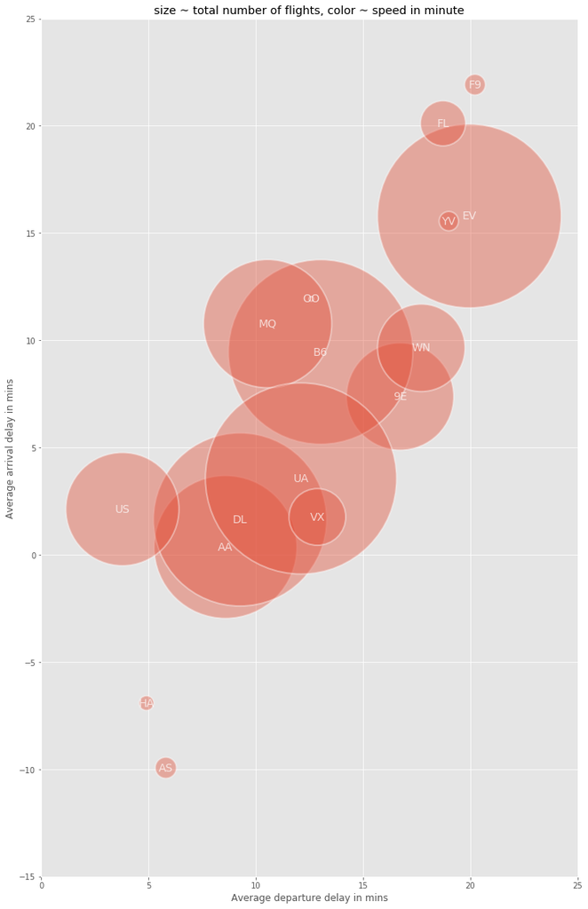

```python
x = list(carrier_avg['dep_delay'])
y = list(carrier_avg['arr_delay'])
area=list(carrier_avg['total_flights_count'])
s=list(carrier_avg['carrier'])

i = 0
while(i<len(carrier_avg)):
    text(x[i],y[i],s[i],size=14, verticalalignment='center', horizontalalignment='center', color='white', alpha = 0.7)
    i = i+1
plt.scatter(x, y, s=area, linewidths=2, edgecolor='w',alpha=0.4)
rcParams['figure.figsize'] = 20, 20 #ensure the whole view of the plot
plt.axes().set_aspect('equal')
axis([0,25,-15,25])
xlabel('Average departure delay in mins')
ylabel('Average arrival delay in mins')
title('size ~ total number of flights, color ~ speed in minute')
```

for destination, the process is similar

```python
dest_avg=flights_df.groupby('dest')['dep_delay','arr_delay','speed'].mean()
dest_avg.reset_index(level=0, inplace=True)
dest_avg
```

|  | dest | dep_delay | arr_delay | speed |
| --- | --- | --- | --- | --- |
| 0 | ABQ | 13.740157 | 4.381890 | 7.370106 |
| 1 | ACK | 6.456604 | 4.852273 | 4.815894 |
| 2 | ALB | 23.620525 | 14.397129 | 4.538350 |
| 3 | ANC | 12.875000 | -2.500000 | 8.166432 |
| 4 | ATL | 12.509824 | 11.300113 | 6.753035 |
| ... | ... | ... | ... | ... |
| 100 | TPA | 12.135007 | 7.408525 | 6.984943 |
| 101 | TUL | 34.906355 | 33.659864 | 6.873666 |
| 102 | TVC | 22.083333 | 12.968421 | 6.901976 |
| 103 | TYS | 28.493955 | 24.069204 | 6.581703 |
| 104 | XNA | 6.464886 | 7.465726 | 6.720233 |

105 rows × 4 columns

```python
dest_avg=dest_avg[np.isfinite(dest_avg.dep_delay)]
dest_avg=dest_avg[np.isfinite(dest_avg.arr_delay)]
dest_avg[np.isfinite(dest_avg.speed)]
```

|  | dest | dep_delay | arr_delay | speed |
| --- | --- | --- | --- | --- |
| 0 | ABQ | 13.740157 | 4.381890 | 7.370106 |
| 1 | ACK | 6.456604 | 4.852273 | 4.815894 |
| 2 | ALB | 23.620525 | 14.397129 | 4.538350 |
| 3 | ANC | 12.875000 | -2.500000 | 8.166432 |
| 4 | ATL | 12.509824 | 11.300113 | 6.753035 |
| ... | ... | ... | ... | ... |
| 100 | TPA | 12.135007 | 7.408525 | 6.984943 |
| 101 | TUL | 34.906355 | 33.659864 | 6.873666 |
| 102 | TVC | 22.083333 | 12.968421 | 6.901976 |
| 103 | TYS | 28.493955 | 24.069204 | 6.581703 |
| 104 | XNA | 6.464886 | 7.465726 | 6.720233 |

104 rows × 4 columns

```python
total_flights_dest = flights_df.groupby('dest').count()
total_flights_dest.reset_index(level=0, inplace=True)
total_flights_dest.rename(columns = {'Unnamed: 0':'count'}, inplace = True)
dest_avg['total_count'] = total_flights_dest['count']
```

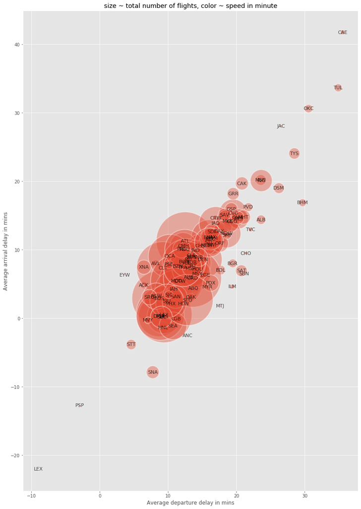

```python
x2 = list(dest_avg['dep_delay'])
y2 = list(dest_avg['arr_delay'])
area2=list(dest_avg['total_count'])
s2=list(dest_avg['dest'])

i = 0
while(i<len(dest_avg)):
    text(x2[i],y2[i],s2[i],size=11, verticalalignment='center', horizontalalignment='center', color='black', alpha = 0.7)
    i = i+1
plt.scatter(x2, y2, s=area2, linewidths=2, edgecolor='w',alpha=0.4)
rcParams['figure.figsize'] = 20, 20
plt.axes().set_aspect('equal')
xlabel('Average departure delay in mins')
ylabel('Average arrival delay in mins')
title('size ~ total number of flights, color ~ speed in minute')
```

People who dislike delays would prefer airlines: UA,VX,DL,US,AA,HA and AS. They would be happy if they are going to airports: LEX, PSP, SNA and STT.

## Question 6

What weather conditions are associated with flight delays leaving NYC? Use graphics to explore.

Note: you need to use 'weather.csv' dataset

```python
# Your code here
weather_df= pd.read_csv('data/weather.csv')
```

```python
# get the average data and group flight information: origin+year+month+day
weather_df=pd.DataFrame(weather_df.groupby(['origin','year','month','day']).mean())
```

```python
#rearrange the columns
weather_df.reset_index(level = 0, inplace = True)
weather_df.reset_index(level = 0, inplace = True)
weather_df.reset_index(level = 0, inplace = True)
weather_df.reset_index(level = 0, inplace = True)
```

```python
#rearrange the column order
weather_df=pd.DataFrame(weather_df[['origin','year','month','day','temp','dewp',
                                    'humid','wind_dir','wind_speed','wind_gust',
                                    'precip','pressure','visib']])
```

```python
weather_df
```

|  | origin | year | month | day | temp | dewp | humid | wind_dir | wind_speed | wind_gust | precip | pressure | visib |
| --- | --- | --- | --- | --- | --- | --- | --- | --- | --- | --- | --- | --- | --- |
| 0 | EWR | 2013 | 1.0 | 1.0 | 38.4800 | 25.050435 | 58.386087 | 263.043478 | 12.758648 | 14.682397 | 0.0 | 1012.442857 | 10.0 |
| 1 | EWR | 2013 | 1.0 | 2.0 | 28.8350 | 11.382500 | 47.786250 | 307.916667 | 12.514732 | 14.401704 | 0.0 | 1017.337500 | 10.0 |
| 2 | EWR | 2013 | 1.0 | 3.0 | 29.4575 | 14.780000 | 54.395833 | 276.956522 | 7.863663 | 9.049346 | 0.0 | 1021.058333 | 10.0 |
| 3 | EWR | 2013 | 1.0 | 4.0 | 33.4775 | 19.205000 | 55.880417 | 242.916667 | 13.857309 | 15.946714 | 0.0 | 1017.533333 | 10.0 |
| 4 | EWR | 2013 | 1.0 | 5.0 | 36.7325 | 19.242500 | 49.284583 | 271.666667 | 10.836512 | 12.470441 | 0.0 | 1021.120833 | 10.0 |
| ... | ... | ... | ... | ... | ... | ... | ... | ... | ... | ... | ... | ... | ... |
| 367 | JFK | 2013 | 7.0 | 31.0 | 71.0600 | 55.040000 | 56.930000 | 320.000000 | 8.055460 | 9.270062 | 0.0 | 1020.400000 | 10.0 |
| 368 | JFK | 2013 | 9.0 | 2.0 | 75.2000 | 73.400000 | 94.140000 | 200.000000 | 4.603120 | 5.297178 | 0.0 | NaN | 4.0 |
| 369 | JFK | 2013 | 10.0 | 23.0 | 48.9200 | 39.020000 | 68.510000 | 50.000000 | 4.603120 | 5.297178 | 0.0 | 1008.300000 | 10.0 |
| 370 | JFK | 2013 | 12.0 | 17.0 | 26.9600 | 10.940000 | 50.340000 | 40.000000 | 4.603120 | 5.297178 | 0.0 | 1023.900000 | 10.0 |
| 371 | LGA | 2013 | 8.0 | 22.0 | 75.9200 | 66.920000 | 73.680000 | 210.000000 | 8.055460 | 9.270062 | 0.0 | 1011.900000 | 10.0 |

372 rows × 13 columns

```python
#arrange the flights_df DataFrame in the same way
flights_mean=flights_df.groupby(['year','month','day','origin']).mean()
flights_mean.reset_index(level = 0, inplace = True)
flights_mean.reset_index(level = 0, inplace = True)
flights_mean.reset_index(level = 0, inplace = True)
flights_mean.reset_index(level = 0, inplace = True)

flights_mean = flights_mean[['origin','year','month','day','dep_delay','arr_delay','speed']]
flights_mean
```

|  | origin | year | month | day | dep_delay | arr_delay | speed |
| --- | --- | --- | --- | --- | --- | --- | --- |
| 0 | EWR | 2013 | 1 | 1 | 17.483553 | 20.886667 | 5.891418 |
| 1 | JFK | 2013 | 1 | 1 | 12.219595 | 8.088136 | 6.227378 |
| 2 | LGA | 2013 | 1 | 1 | 3.134454 | 7.885593 | 5.701970 |
| 3 | EWR | 2013 | 1 | 2 | 25.322674 | 25.439883 | 5.955132 |
| 4 | JFK | 2013 | 1 | 2 | 8.143750 | 3.268139 | 6.331770 |
| ... | ... | ... | ... | ... | ... | ... | ... |
| 1090 | JFK | 2013 | 12 | 30 | 9.604502 | 8.141935 | 6.322723 |
| 1091 | LGA | 2013 | 12 | 30 | 4.855705 | 6.275168 | 5.916681 |
| 1092 | EWR | 2013 | 12 | 31 | 9.776923 | 10.288462 | 6.170129 |
| 1093 | JFK | 2013 | 12 | 31 | 7.842857 | 9.333333 | 6.212847 |
| 1094 | LGA | 2013 | 12 | 31 | 2.631818 | -2.563636 | 6.011691 |

1095 rows × 7 columns

```python
#merge the two DataFrames
flights_weather = pd.merge(weather_df,flights_mean, on = ['year','month','day','origin'], how = 'inner')
```

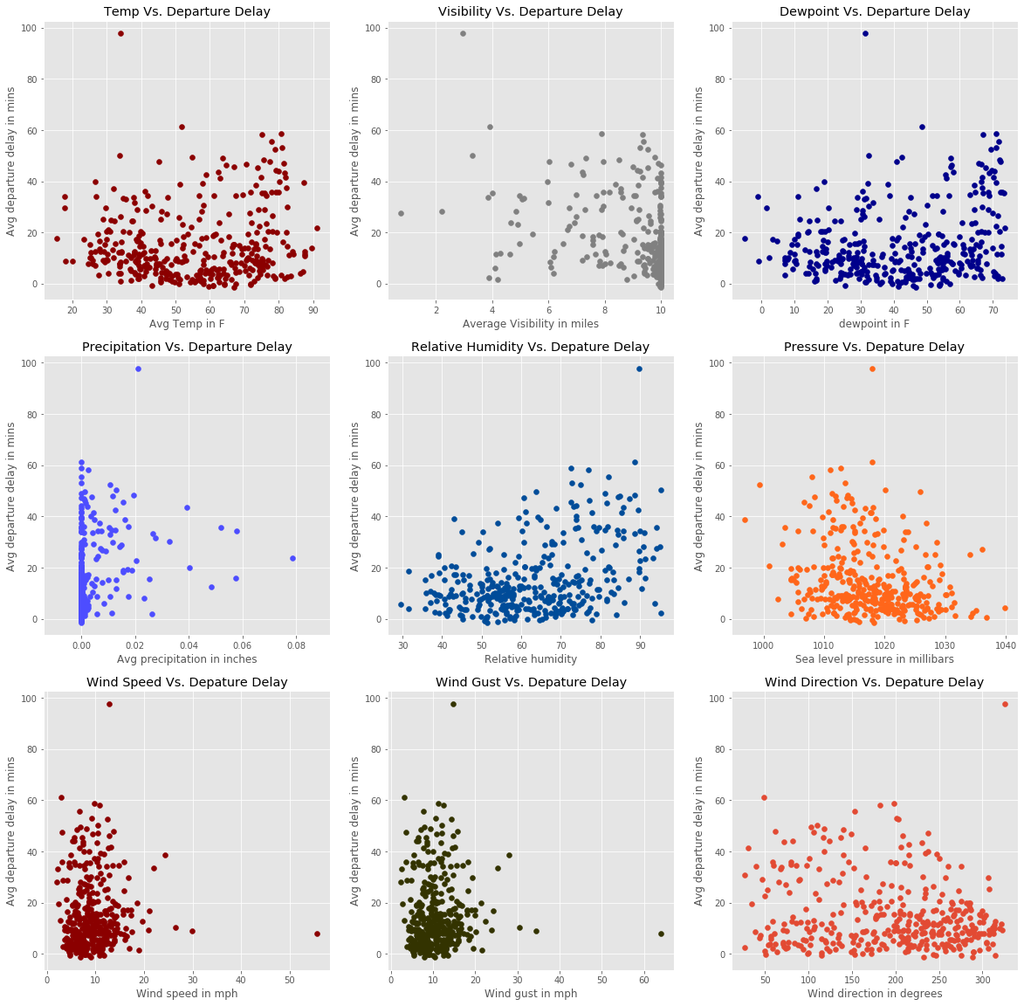

```python
#get ready to plot
matplotlib.style.use('ggplot')
rcParams['figure.figsize'] = 20, 20
fig = plt.figure()

# research the relationship in seperate plots

ax1 = fig.add_subplot(331)
ax1.scatter(flights_weather['temp'], flights_weather['dep_delay'], c = 'darkred')
xlabel('Avg Temp in F')
ylabel('Avg departure delay in mins')
title('Temp Vs. Departure Delay')

ax2 = fig.add_subplot(332)
ax2.scatter(flights_weather['visib'], flights_weather['dep_delay'], c = 'grey')
xlabel('Average Visibility in miles')
ylabel('Avg departure delay in mins')
title('Visibility Vs. Departure Delay')

ax3 = fig.add_subplot(333)
ax3.scatter(flights_weather['dewp'],flights_weather['dep_delay'], c = 'darkblue')
xlabel('dewpoint in F')
ylabel('Avg departure delay in mins')
title('Dewpoint Vs. Departure Delay')

ax4 = fig.add_subplot(334)
ax4.scatter(flights_weather['precip'], flights_weather['dep_delay'], c = '#4d4dff')
xlabel('Avg precipitation in inches')
ylabel('Avg departure delay in mins')
title('Precipitation Vs. Departure Delay')

ax5 = fig.add_subplot(335)
ax5.scatter(flights_weather['humid'], flights_weather['dep_delay'], c = '#004c99')
xlabel('Relative humidity')
ylabel('Avg departure delay in mins')
title('Relative Humidity Vs. Depature Delay')

ax6 = fig.add_subplot(336)
ax6.scatter(flights_weather['pressure'], flights_weather['dep_delay'], c = '#ff661a')
xlabel('Sea level pressure in millibars')
ylabel('Avg departure delay in mins')
title('Pressure Vs. Depature Delay')

ax7 = fig.add_subplot(337)
ax7.scatter(flights_weather['wind_speed'], flights_weather['dep_delay'], c = 'darkred')
xlabel('Wind speed in mph')
ylabel('Avg departure delay in mins')
title('Wind Speed Vs. Depature Delay')

ax8 = fig.add_subplot(338)
ax8.scatter(flights_weather['wind_gust'], flights_weather['dep_delay'], c = '#333300')
xlabel('Wind gust in mph')
ylabel('Avg departure delay in mins')
title('Wind Gust Vs. Depature Delay')

ax9 = fig.add_subplot(339)
ax9.scatter(flights_weather['wind_dir'], flights_weather['dep_delay'])
xlabel('Wind direction in degrees')
ylabel('Avg departure delay in mins')
title('Wind Direction Vs. Depature Delay')
```

```python
# Run regression models to find out the exact influence of each weather condition

lm1 = smf.ols(formula='dep_delay ~ temp', data=flights_weather).fit()
print ("The regression coefficients for the dep_delay~temp model (Graph 1) are:\n\n", lm1.params)

lm2 = smf.ols(formula='dep_delay ~ visib', data=flights_weather).fit()
print ("\n\nThe regression coefficients for the dep_delay~visib model (Graph 2) are:\n\n", lm2.params)

lm3 = smf.ols(formula='dep_delay ~ dewp', data=flights_weather).fit()
print ("\n\nThe regression coefficients for the dep_delay~dewp model (Graph 3) are:\n\n", lm3.params)

lm4 = smf.ols(formula='dep_delay ~ precip', data=flights_weather).fit()
print ("\n\nThe regression coefficients for the dep_delay~precip model (Graph 4) are:\n\n", lm4.params)

lm5 = smf.ols(formula='dep_delay ~ humid', data=flights_weather).fit()
print ("\n\nThe regression coefficients for the dep_delay~humid model (Graph 5) are:\n\n", lm5.params)

lm6 = smf.ols(formula='dep_delay ~ pressure', data=flights_weather).fit()
print ("\n\nThe regression coefficients for the dep_delay~pressure model (Graph 6) are:\n\n", lm6.params)

lm7 = smf.ols(formula='dep_delay ~ wind_speed', data=flights_weather).fit()
print ("\n\nThe regression coefficients for the dep_delay~wind_speed model (Graph 7) are:\n\n", lm7.params)

lm8 = smf.ols(formula='dep_delay ~ wind_gust', data=flights_weather).fit()
print ("\n\nThe regression coefficients for the dep_delay~wind_gust model (Graph 8) are:\n\n", lm8.params)

lm9 = smf.ols(formula='dep_delay ~ wind_dir', data=flights_weather).fit()
print ("\n\nThe regression coefficients for the dep_delay~wind_dir model (Graph 9) are:\n\n", lm9.params)
```

```
The regression coefficients for the dep_delay~temp model (Graph 1) are:

 Intercept    10.720439
temp          0.080707
dtype: float64


The regression coefficients for the dep_delay~visib model (Graph 2) are:

 Intercept    46.574289
visib        -3.409740
dtype: float64


The regression coefficients for the dep_delay~dewp model (Graph 3) are:

 Intercept    8.632177
dewp         0.157130
dtype: float64


The regression coefficients for the dep_delay~precip model (Graph 4) are:

 Intercept     13.865579
precip       447.586244
dtype: float64


The regression coefficients for the dep_delay~humid model (Graph 5) are:

 Intercept   -9.157928
humid        0.387205
dtype: float64


The regression coefficients for the dep_delay~pressure model (Graph 6) are:

 Intercept    520.109715
pressure      -0.496313
dtype: float64


The regression coefficients for the dep_delay~wind_speed model (Graph 7) are:

 Intercept     14.876774
wind_speed     0.033627
dtype: float64


The regression coefficients for the dep_delay~wind_gust model (Graph 8) are:

 Intercept    14.876774
wind_gust     0.029221
dtype: float64


The regression coefficients for the dep_delay~wind_dir model (Graph 9) are:

 Intercept    20.182212
wind_dir     -0.025905
dtype: float64
```

From lm1 to lm9 along with the nine plots, the relationship between departure delays and the weather factors are as follows:

1. Temp vs. Departure Delay:
   - For every 1 degree F increase in the temperature, the departure delay increases by 0.080 mins.
   - On a day when the temperature is 0F, the avg dep delay is expected to be around 10.72.
2. Visibility vs. Departure Delay:
   - For every 1 mile increase in visibility, the dep delay decreases by 3.40 mins.
   - On a day with 0 mile visibility, the dep delay is expected to be 46.57 mins.
3. Dewpoint Vs. Departure Delay:
   - For every 1 degree increase in dewpoint value, the dep delay increases by 0.15 mins.
   - For a day with dewpoint value as 0, the dep delay is expected to be 8.63 mins.
4. Precipitation Vs. Departure Delay:
   - For every 1 inch increase in precipitation in a day, the avg departure delay is expected to increase by 447.58 mins. (ie, 1 inch is considerable rain for NY)
   - On a day with 0 inch rain, the departure delay is expected to be around 13.86 mins.
5. Humidity Vs. Departure Delay:
   - For every 1 unit increase in the value of humidity, the dep delay is expected to increase by 0.387 mins.
   - On a day with no humidity, the departure delay is expected to be -9.15 mins (ie, early departure).
6. Pressure Vs. Departure Delay:
   - For every 1 unit increase in pressure, the dep delay is expected to decrease by 0.49 mins.
   - On a day with 0 pressure, 520.10 mins is the expected departure delay (although this situation may not be possible)
7. Wind Speed Vs. Departure Delay:
   - For every 1 mph increase in the wind speed, the departure delay increases by 0.03 mins.
   - On a day with no wind (wind 0 mph), the departure delay is expected to be 14.87 mins.
8. Wind Gust Vs. Depature Delay:
   - For every 1 mph increase in the wind gust value, the dep delay increases by 0.02 mins.
   - For 0 mph wind gust, the departure delay is expected to be 14.87 mins.
9. Wind Direction Vs. Departure Delay:
   - For every 1 degree change in the direction of the wind, the dep delay decreases by 0.025 mins.
   - On a day when the wind is flowing in 0 degrees, the departure delay is expected to be 20.18 mins.

According to my observations, the precip, visibility and dewpoint have more obvious influence on the delay.  
Let's run a multivariate linear regression model.

```python
import statsmodels.formula.api as smf
lm = smf.ols(formula='dep_delay ~ dewp + visib + precip', data=flights_weather).fit()
lm.summary()
```

OLS Regression Results

| Dep. Variable: | dep_delay | R-squared: | 0.192 |
| --- | --- | --- | --- |
| Model: | OLS | Adj. R-squared: | 0.185 |
| Method: | Least Squares | F-statistic: | 29.12 |
| Date: | Thu, 16 Jan 2020 | Prob (F-statistic): | 6.48e-17 |
| Time: | 14:00:52 | Log-Likelihood: | -1466.6 |
| No. Observations: | 372 | AIC: | 2941. |
| Df Residuals: | 368 | BIC: | 2957. |
| Df Model: | 3 |  |  |
| Covariance Type: | nonrobust |  |  |

|  | coef | std err | t | P>\|t\| | [0.025 | 0.975] |
| --- | --- | --- | --- | --- | --- | --- |
| Intercept | 34.5837 | 4.741 | 7.294 | 0.000 | 25.260 | 43.907 |
| dewp | 0.1170 | 0.034 | 3.443 | 0.001 | 0.050 | 0.184 |
| visib | -2.7058 | 0.461 | -5.865 | 0.000 | -3.613 | -1.799 |
| precip | 211.5438 | 81.816 | 2.586 | 0.010 | 50.658 | 372.430 |

| Omnibus: | 82.507 | Durbin-Watson: | 1.294 |
| --- | --- | --- | --- |
| Prob(Omnibus): | 0.000 | Jarque-Bera (JB): | 156.373 |
| Skew: | 1.206 | Prob(JB): | 1.11e-34 |
| Kurtosis: | 5.066 | Cond. No. | 5.89e+03 |

Warnings:  
[1] Standard Errors assume that the covariance matrix of the errors is correctly specified.  
[2] The condition number is large, 5.89e+03. This might indicate that there are  
strong multicollinearity or other numerical problems.

Seems like it's not a good choice. Replace dewp with pressure and try again.

```python
lmm = smf.ols(formula='dep_delay ~ pressure + visib + precip', data=flights_weather).fit()
lmm.summary()
```

OLS Regression Results

| Dep. Variable: | dep_delay | R-squared: | 0.197 |
| --- | --- | --- | --- |
| Model: | OLS | Adj. R-squared: | 0.191 |
| Method: | Least Squares | F-statistic: | 30.01 |
| Date: | Thu, 16 Jan 2020 | Prob (F-statistic): | 2.28e-17 |
| Time: | 14:03:30 | Log-Likelihood: | -1456.9 |
| No. Observations: | 370 | AIC: | 2922. |
| Df Residuals: | 366 | BIC: | 2937. |
| Df Model: | 3 |  |  |
| Covariance Type: | nonrobust |  |  |

|  | coef | std err | t | P>\|t\| | [0.025 | 0.975] |
| --- | --- | --- | --- | --- | --- | --- |
| Intercept | 431.0262 | 96.298 | 4.476 | 0.000 | 241.660 | 620.392 |
| pressure | -0.3831 | 0.095 | -4.047 | 0.000 | -0.569 | -0.197 |
| visib | -2.8816 | 0.494 | -5.837 | 0.000 | -3.852 | -1.911 |
| precip | 169.7380 | 83.813 | 2.025 | 0.044 | 4.923 | 334.553 |

| Omnibus: | 89.293 | Durbin-Watson: | 1.351 |
| --- | --- | --- | --- |
| Prob(Omnibus): | 0.000 | Jarque-Bera (JB): | 179.232 |
| Skew: | 1.277 | Prob(JB): | 1.20e-39 |
| Kurtosis: | 5.259 | Cond. No. | 1.56e+05 |

Warnings:  
[1] Standard Errors assume that the covariance matrix of the errors is correctly specified.  
[2] The condition number is large, 1.56e+05. This might indicate that there are  
strong multicollinearity or other numerical problems.

The condition number is bigger this time. So, forget about it.

```python
llmm = smf.ols(formula='dep_delay ~ temp + visib + precip', data=flights_weather).fit()
llmm.summary()
```

OLS Regression Results

| Dep. Variable: | dep_delay | R-squared: | 0.183 |
| --- | --- | --- | --- |
| Model: | OLS | Adj. R-squared: | 0.176 |
| Method: | Least Squares | F-statistic: | 27.41 |
| Date: | Thu, 16 Jan 2020 | Prob (F-statistic): | 5.11e-16 |
| Time: | 14:07:33 | Log-Likelihood: | -1468.7 |
| No. Observations: | 372 | AIC: | 2945. |
| Df Residuals: | 368 | BIC: | 2961. |
| Df Model: | 3 |  |  |
| Covariance Type: | nonrobust |  |  |

|  | coef | std err | t | P>\|t\| | [0.025 | 0.975] |
| --- | --- | --- | --- | --- | --- | --- |
| Intercept | 36.1175 | 4.726 | 7.642 | 0.000 | 26.824 | 45.411 |
| temp | 0.1021 | 0.037 | 2.751 | 0.006 | 0.029 | 0.175 |
| visib | -2.9599 | 0.464 | -6.386 | 0.000 | -3.871 | -2.048 |
| precip | 222.9560 | 82.151 | 2.714 | 0.007 | 61.412 | 384.500 |

| Omnibus: | 84.849 | Durbin-Watson: | 1.283 |
| --- | --- | --- | --- |
| Prob(Omnibus): | 0.000 | Jarque-Bera (JB): | 161.613 |
| Skew: | 1.238 | Prob(JB): | 8.06e-36 |
| Kurtosis: | 5.073 | Cond. No. | 7.40e+03 |

Warnings:  
[1] Standard Errors assume that the covariance matrix of the errors is correctly specified.  
[2] The condition number is large, 7.4e+03. This might indicate that there are  
strong multicollinearity or other numerical problems.

Considering the condition number, the fomula lm: dep_delay ~ dewp + visib + precip is the one better to analyze. The p-value of the three variates are all below 0.05. They are of statistically significance.

- Holding dewpoint and precipitation constant, for every 1 mile increase in visibility leads to a drop in departure delays by 2.7 mins.
- For every 1 inch increase in precipitation, the departure delays increase drastically by 211.5 mins, holding other two parameters constant.
- For every degree rise in dewpoint, the departure delays increase by 0.12 mins, holding holding other two parameters constant.

# Grading

- Q1: 1pt each question (5 in total)
- Q2: a) 2pt, b) 3pt, c) 2pt, d) 2pt, e) 1pt
- Q3: 5pt
- Q4: 5pt
- Q5: 15pt
- Q6: 10pt